# CaseStudy1 - MSDS 6306

Robert Flamenbaum

March 7, 2017

# Introduction

Gross Domestic Product or GDP, measures the amount of goods and material that is produced by a country. This value is measured over the course of a year or quarter and is typically used as an indicator of the wealth of a nation. The amount people earned or spent are usually used in GDP calculations. While GDP is an excellent indicator of the overall productivity of a nation, it is possible that it falls short as a measure of quality of life, education, and overall intrinsic wealth. This study seeks to measure GDP against other measures such as income groups. We will seek to find out if there exists a disparity between GDP and income groups. This study will shed a light on whether the productivity of a nation is a good indication of the overall wealth of the individuals belonging to that nation.

# Objectives

Throughout the course of this study, a series of 5 tasks and questions will be addressed. These questions are listed below.

1. Merge the data based on the country shortcode. How many of the IDs match?
2. Sort the data frame in ascending order by GDP (so United States is last). What is the 13th country in the resulting data frame?
3. What are the average GDP rankings for the “High income: OECD” and “High income: nonOECD” groups?
4. Plot the GDP for all of the countries. Use ggplot2 to color your plot by Income Group.
5. Cut the GDP ranking into 5 separate quantile groups. Make a table versus Income.Group. How many countries are Lower middle income but among the 38 nations with highest GDP?

## Downloading and cleaning the data

### Step 1: Install and load necessary packages:

To start, load downloader, repmis and RCurl. Other packages will be added as necessary.

```r
library(repmis)
library(RCurl)
library(downloader)
```

### Download and create tidy data sets

The steps for creating tidy data are listed below.  
First the data is saved as CSV files. Next, the CSV’s are loaded into a data frame. Once the data is in a data frame, remove missing rows and columns. Next, it is wise to rename the columns using meaningful names.  
It is important to scan your columns and make sure the data types are in the format needed for the analysis you intend to run. Convert any character data types to numeric and factors as you see fit. In the analysis below, I converted both Economy and Rank to numeric fields. Notice how I removed the commas from the Economy attributes prior to converting the data. The commas were being factored into the data conversion and produced incorrect results when converting to numeric data.

Source URL’s are https://d396qusza40orc.cloudfront.net/getdata%2Fdata%2FGDP.csv

https://d396qusza40orc.cloudfront.net/getdata%2Fdata%2FEDSTATS_Country.csv

```r
download("https://d396qusza40orc.cloudfront.net/getdata%2Fdata%2FGDP.csv", destfile="gdp.csv")
download("https://d396qusza40orc.cloudfront.net/getdata%2Fdata%2FEDSTATS_Country.csv", destfile="educ.csv")
list.files()
```

```
##  [1] "Analysis"               "CaseStudy1.Rproj"
##  [3] "CaseStudy1_Output.html" "CaseStudy1_Output.Rmd"
##  [5] "Data_Cleaning"          "educ.csv"
##  [7] "gdp.csv"                "Paper"
##  [9] "Raw_Data"               "README.md"
```

```r
# Load gdp data into gdpraw dataframe

gdpraw <-read.csv("gdp.csv", stringsAsFactors = FALSE, header = FALSE)
str(gdpraw)
```

```
## 'data.frame':    331 obs. of  10 variables:
##  $ V1 : chr  "" "" "" "" ...
##  $ V2 : chr  "Gross domestic product 2012" "" "" "Ranking" ...
##  $ V3 : logi  NA NA NA NA NA NA ...
##  $ V4 : chr  "" "" "" "Economy" ...
##  $ V5 : chr  "" "" "(millions of" "US dollars)" ...
##  $ V6 : chr  "" "" "" "" ...
##  $ V7 : logi  NA NA NA NA NA NA ...
##  $ V8 : logi  NA NA NA NA NA NA ...
##  $ V9 : logi  NA NA NA NA NA NA ...
##  $ V10: logi  NA NA NA NA NA NA ...
```

```r
dim(gdpraw)
```

```
## [1] 331  10
```

```r
head(gdpraw)
```

```
##    V1                          V2 V3            V4           V5 V6 V7 V8
## 1     Gross domestic product 2012 NA                               NA NA
## 2                                 NA                               NA NA
## 3                                 NA               (millions of    NA NA
## 4                         Ranking NA       Economy  US dollars)    NA NA
## 5                                 NA                               NA NA
## 6 USA                           1 NA United States  16,244,600     NA NA
##   V9 V10
## 1 NA  NA
## 2 NA  NA
## 3 NA  NA
## 4 NA  NA
## 5 NA  NA
## 6 NA  NA
```

```r
tail(gdpraw)
```

```
##     V1 V2 V3 V4 V5 V6 V7 V8 V9 V10
## 326       NA          NA NA NA  NA
## 327       NA          NA NA NA  NA
## 328       NA          NA NA NA  NA
## 329       NA          NA NA NA  NA
## 330       NA          NA NA NA  NA
## 331       NA          NA NA NA  NA
```

```r
# Clean out missing data in both rows and columns

gdp <- gdpraw[6:195, c("V1","V2","V4","V5")]
head(gdp)
```

```
##     V1 V2             V4           V5
## 6  USA  1  United States  16,244,600
## 7  CHN  2          China   8,227,103
## 8  JPN  3          Japan   5,959,718
## 9  DEU  4        Germany   3,428,131
## 10 FRA  5         France   2,612,878
## 11 GBR  6 United Kingdom   2,471,784
```

```r
# Rename variables to be more meaningful
# Load dplyr

library(dplyr)
gdp <- rename(gdp, CountryCode=V1, Rank=V2, CountryFullName=V4, Economy=V5)

#Remove commas from Economy Column - These cause problems during Character to numeric conversion
gdp$Economy <- gsub(",", "", gdp$Economy)

#Convert Economy from Character to Numeric data type
gdp$Economy <- as.numeric(gdp$Economy)

#Convert Rank from Character to Numeric data type
gdp$Rank <- as.integer(gdp$Rank)

head(gdp)
```

```
##    CountryCode Rank CountryFullName  Economy
## 6          USA    1   United States 16244600
## 7          CHN    2           China  8227103
## 8          JPN    3           Japan  5959718
## 9          DEU    4         Germany  3428131
## 10         FRA    5          France  2612878
## 11         GBR    6  United Kingdom  2471784
```

### Load education data into a data frame named educraw

The education data set has 234 rows and 31 columns. For our analysis, we do not need all 31 columns. To proceed with the analysis, the education data will be subset into a new data frame called educ that contains only 2 columns. One column contains the country code that will be used to merge the data set with the gdp data set. The other column, “Income.Group”, will be used to create bins of data further along in our analysis.

#### A note about NA attributes

Though the education data set has a plethora of NA’s, we will not remove them using the complete.cases or na.omit statements. By omiting the extraneous columns in the data frame, we have effectively removed NA values without removing valuable rows that will be needed to merge our data later on in our analysis.

```r
educraw <-read.csv("educ.csv", stringsAsFactors = FALSE, header = TRUE)
str(educraw)
```

```
## 'data.frame':    234 obs. of  31 variables:
##  $ CountryCode                                      : chr  "ABW" "ADO" "AFG" "AGO" ...
##  $ Long.Name                                        : chr  "Aruba" "Principality of Andorra" "Islamic State of Afghanistan" "People's Republic of Angola" ...
##  $ Income.Group                                     : chr  "High income: nonOECD" "High income: nonOECD" "Low income" "Lower middle income" ...
##  $ Region                                           : chr  "Latin America & Caribbean" "Europe & Central Asia" "South Asia" "Sub-Saharan Africa" ...
##  $ Lending.category                                 : chr  "" "" "IDA" "IDA" ...
##  $ Other.groups                                     : chr  "" "" "HIPC" "" ...
##  $ Currency.Unit                                    : chr  "Aruban florin" "Euro" "Afghan afghani" "Angolan kwanza" ...
##  $ Latest.population.census                         : chr  "2000" "Register based" "1979" "1970" ...
##  $ Latest.household.survey                          : chr  "" "" "MICS, 2003" "MICS, 2001, MIS, 2006/07" ...
##  $ Special.Notes                                    : chr  "" "" "Fiscal year end: March 20; reporting period for national accounts data: FY." "" ...
##  $ National.accounts.base.year                      : chr  "1995" "" "2002/2003" "1997" ...
##  $ National.accounts.reference.year                 : int  NA NA NA NA 1996 NA NA 1996 NA NA ...
##  $ System.of.National.Accounts                      : int  NA NA NA NA 1993 NA 1993 1993 NA NA ...
##  $ SNA.price.valuation                              : chr  "" "" "VAB" "VAP" ...
```

[output cut: 17 more lines]

```r
dim(educraw)
```

```
## [1] 234  31
```

```r
##Drop NA Values Problem - This removes all but 14 rows. NA's will be removed by omtting extraneous columns.
##educNoNA <- educraw[complete.cases(educraw),]
##head(educNoNA)

#New code to bring in only the pertinent variables for the study

educ <-  educraw[, c("CountryCode","Income.Group")]
head(educ)
```

```
##   CountryCode         Income.Group
## 1         ABW High income: nonOECD
## 2         ADO High income: nonOECD
## 3         AFG           Low income
## 4         AGO  Lower middle income
## 5         ALB  Upper middle income
## 6         ARE High income: nonOECD
```

# Analysis

## Question 1:

Merge the data based on the country shortcode. How many of the IDs match?

```r
# gdp_educ <- merge(gdp, educNoNA)
#head(gdp_educ)
#gdp_educ
#educNoNA

gdp_educraw <- merge(gdp, educ)
head(gdp_educraw)
```

```
##   CountryCode Rank      CountryFullName Economy         Income.Group
## 1         ABW  161                Aruba    2584 High income: nonOECD
## 2         AFG  105          Afghanistan   20497           Low income
## 3         AGO   60               Angola  114147  Lower middle income
## 4         ALB  125              Albania   12648  Upper middle income
## 5         ARE   32 United Arab Emirates  348595 High income: nonOECD
## 6         ARG   26            Argentina  475502  Upper middle income
```

## Question 2:

Sort the data frame in ascending order by GDP (so United States is last). What is the 13th country in the resulting data frame?

## Answer: St. Kitts and Nevis

To obtain this answer, it is necessary to convert the Economy variable to a numeric data type and then sort ascending so that the highest GDP is last in the list. Once sorted, the 13th record is St. Kitts and Nevis.

```r
order_gdp <-order(gdp_educraw$Economy)

head (gdp_educraw[order_gdp,])
```

```
##     CountryCode Rank       CountryFullName Economy        Income.Group
## 173         TUV  190                Tuvalu      40 Lower middle income
## 92          KIR  189              Kiribati     175 Lower middle income
## 113         MHL  188      Marshall Islands     182 Lower middle income
## 137         PLW  187                 Palau     228 Upper middle income
## 155         STP  186 São Tomé and Principe     263 Lower middle income
## 59          FSM  185 Micronesia, Fed. Sts.     326 Lower middle income
```

```r
# gdp_educraw [13,] This code returns the original position of the record, not the newly sorted position
```

## Question 3:

What are the average GDP rankings for the “High income: OECD” and “High income: nonOECD” groups?

## Answer:

Average Rank of High Income OECD group: 32.9667  
Average Rank of High Income nonOECD group: 91.91304

Note: To obtain this answer, the data was subsetted into 2 data frames called HighIncome_OECD and HighIncome_nonOECD. Data containing only records with Income.Group equal to HighIncome: OECD was subset or queried and stored in the HighIncome_OECD data frame. Data containing only records with Income.Group equal to HighIncome: nonOECD was subset or queried and stored in the HighIncome_nonOECD data frame. Subsequently, the mean was taken of both data frames to obtain the answers 32.9667 and 91.91304.

The inferences that could be made about this analysis is that the HighIncome: OECD have a much better GDP ranking than the HighIncome: nonOECD group. In fact, the average rank of HighIncome: OECD is nearly 3 times as better as HighIncome: nonOECD.

```r
HighIncome_OECD <- subset(x=gdp_educraw, Income.Group == 'High income: OECD')
mean(HighIncome_OECD$Rank)
```

```
## [1] 32.96667
```

```r
HighIncome_nonOECD <- subset(x=gdp_educraw, Income.Group == 'High income: nonOECD')
mean(HighIncome_nonOECD$Rank)
```

```
## [1] 91.91304
```

## Question 4:

Plot the GDP for all of the countries. Use ggplot2 to color your plot by Income Group.

## Answer:

Looking at the graph below, it is apparent that there are 4 distinct outliers with very high GDP’s. The GDP numbers drop sharply until around the 25th ranked country. The numbers continue to drop steadily until around the 50th ranked country and then the numbers stay relatively flat-lined until the last country.

The logical deduction that can be made from this graph is that there are only a few very wealthy nations in the world and about 20 fairly wealthy nations, however, the vast majority of nations have an extremely low GDP compared to the wealthy nations.

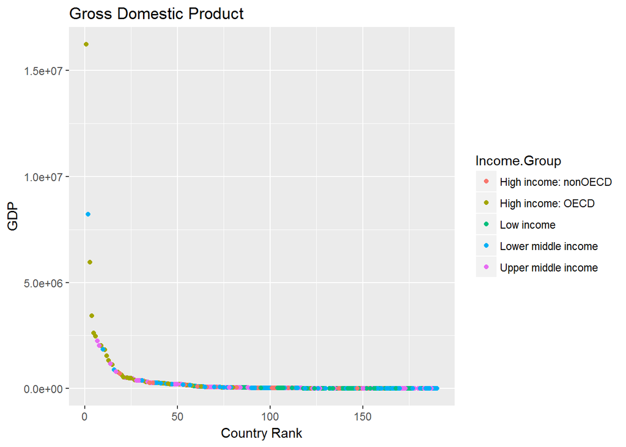

```r
#Istall and load ggplot2

library("ggplot2")
ggplot(gdp_educraw, aes(x = Rank, y = Economy, colour = Income.Group)) + geom_point() + ggtitle("Gross Domestic Product")+  labs(x="Country Rank",y="GDP")
```

## Question 5:

Cut the GDP ranking into 5 separate quantile groups. Make a table versus Income.Group. How many countries are Lower middle income but among the 38 nations with highest GDP?

## Answer:

5 Countries are in the lower middle income group and also in the highest ranked GDP.

The logical conclusion that can be made regarding this analysis is that even though a country has a high GDP, it does not guarantee that people dwelling in these nations have a high income.

```r
# Sort the data in ascending order on Rank

order_rank <-order(gdp_educraw$Rank)
order_rank
```

```
##   [1] 178  34  87  45  58  61  25 145  84  78  31   9  53 112  94  77 172
##  [18] 128 147  32 159  80 129 139  13   6  10 186 181  38 165   5  47 123
##  [35] 150  33  72  51 126  83 136  68  56 133 141  79  81  49 135  88  44
##  [52] 144 176 143 131  96 182  76  16   3 140 107 157  50 162 132  42  11
##  [69]  21 101  74  48 148 104 179  17  70 177 171 158  41 106  98 103  55
##  [86]  63  89 154 134 185 167  86  18 105 174  24 142  36  35 153 170  43
## [103]  54 188   2 175 130  73  60  67  20 187  27  62 138  85  29 119 149
## [120]  91  37  82 124 163   4 127 121  15 115 118 110   7 189 114  97 116
## [137]  19  75  14 109 146 166 125  90  95 108  64  23 156 117 122  26 120
## [154]  57 164 152 160  52  71   1  12 102 111  30  40  28  99  22 168 100
## [171]   8 161 151  65  66 183  69  93 180 184  39  46 169  59 155 137 113
## [188]  92 173
```

```r
head(gdp_educraw[order_rank,])
```

```
##     CountryCode Rank CountryFullName  Economy        Income.Group
## 178         USA    1   United States 16244600   High income: OECD
## 34          CHN    2           China  8227103 Lower middle income
## 87          JPN    3           Japan  5959718   High income: OECD
## 45          DEU    4         Germany  3428131   High income: OECD
## 58          FRA    5          France  2612878   High income: OECD
## 61          GBR    6  United Kingdom  2471784   High income: OECD
```

```r
# Cut the data into 5 equal quantile groups

gdp_rank <- cut(gdp_educraw$Rank, 5, include.lowest = TRUE, labels = c("Rank_Highest", "Rank_MedHigh", "Rank_Medium", "Rank_MedLow", "Rank_Lowest"))

# Append gdp_rank list as a variable called rank_group to gdp_educraw data frame

gdp_educraw$rank_group <- gdp_rank

# Create table with variables Income.Group and rank_group

IncomeGroup_RankGroup <- gdp_educraw[, c("Income.Group", "rank_group")]

# Convert Income.Group and rank_group to factors for subsetting

IncomeGroup_RankGroup$Income.Group <- as.factor(IncomeGroup_RankGroup$Income.Group)

# Subset records where Income.Group is lower middle and rank_group is highest

Low_High <- subset(IncomeGroup_RankGroup, Income.Group == "Lower middle income" & rank_group == "Rank_Highest",select=Income.Group:rank_group)

Low_High
```

```
##            Income.Group   rank_group
## 34  Lower middle income Rank_Highest
## 51  Lower middle income Rank_Highest
## 77  Lower middle income Rank_Highest
## 78  Lower middle income Rank_Highest
## 165 Lower middle income Rank_Highest
```

## Conclusion:

The data in this study and analysis suggests that while GDP is a good indicator of the wealth of a country, it can overlook other indications of wealth, such as overall income. As seen in question 5, 5 of the highest ranked GDP nations are also in the lower middle income group. This suggests that the money earned or spent within these nations is not reflected upon the income of the general public. Further analysis is needed to determine causes for this apparent anomaly.

Another observation that can be made from the analysis in this study is that wealth amongst the nations of the world is in the hands of a minority of nations. The majority of nations have a very low GDP compared to the highest ranked GDP nations.

## References:

The World Bank Website: Description of income groups. https://datahelpdesk.worldbank.org/knowledgebase/articles/906519-world-bank-country-and-lending-groups

Investopedia. What is GDP and why is it so important to economists and investors?  
http://www.investopedia.com/ask/answers/199.asp